# SDS 192: Homework #4

Thao Phan

4/7/2017

```r
library(mdsr)
library(RMySQL)
```

```r
db <- dbConnect_scidb(dbname = "imdb")
library(dplyr)
library(ggplot2)
```

```r
class(db)
```

```
## [1] "MySQLConnection"
## attr(,"package")
## [1] "RMySQL"
```

### compute # of films for each production_year

### store result as data frame with 2 columns: production_year & num_films

```r
totalfilms <- db%>%
  dbGetQuery("SELECT production_year, sum(1) as num_films
              FROM title
              GROUP BY production_year");
```

### Number of films for each production_year table

```r
totalfilms
```

```
##     production_year num_films
## 1                NA    229459
## 2              1874         1
## 3              1878         1
## 4              1883         1
## 5              1887         1
## 6              1888         5
## 7              1889         2
## 8              1890         6
## 9              1891        10
## 10             1892         9
## 11             1893         2
## 12             1894        94
## 13             1895       117
## 14             1896       828
```

[output cut: 130 more lines]

### Compute # of westerns for each production_year.

### Store result as data frame w/2 columns: production year & num_westerns

```r
westerns <- db%>%
  dbGetQuery("SELECT production_year, sum(1) as num_westerns
              FROM movie_info mi
              JOIN title t ON t.id = mi.movie_id
              WHERE mi.info_type_id = 3 AND mi.info LIKE '%western%'
              GROUP BY production_year");
```

### Number of western films for each production_year table

```r
westerns
```

```
##     production_year num_westerns
## 1                NA          307
## 2              1894            1
## 3              1899            4
## 4              1901            1
## 5              1903            8
## 6              1904            4
## 7              1905            3
## 8              1906            8
## 9              1907           20
## 10             1908           49
## 11             1909          107
## 12             1910          389
## 13             1911          524
## 14             1912          588
```

[output cut: 108 more lines]

### Join the results from the previous two questions on production_year (using dplyr – not SQL).

```r
new_table <- totalfilms %>%
  inner_join(westerns, by = "production_year")
```

### newly joined table

```r
new_table
```

```
##     production_year num_films num_westerns
## 1                NA    229459          307
## 2              1894        94            1
## 3              1899      1792            4
## 4              1901      1752            1
## 5              1903      2662            8
## 6              1904      1828            4
## 7              1905      1704            3
## 8              1906      1855            8
## 9              1907      2478           20
## 10             1908      4272           49
## 11             1909      5415          107
## 12             1910      6401          389
## 13             1911      6436          524
## 14             1912      8436          588
```

[output cut: 108 more lines]

### Compute the percentage of movies in each year that are Westerns.

```r
ratio_table <-new_table %>%
  group_by(production_year) %>%
  mutate(ratio = (num_westerns/num_films)*100 )
```

### % of movies that are westerns table

```r
ratio_table
```

```
## Source: local data frame [122 x 4]
## Groups: production_year [122]
##
##    production_year num_films num_westerns      ratio
##              <int>     <dbl>        <dbl>      <dbl>
## 1               NA    229459          307 0.13379297
## 2             1894        94            1 1.06382979
## 3             1899      1792            4 0.22321429
## 4             1901      1752            1 0.05707763
## 5             1903      2662            8 0.30052592
## 6             1904      1828            4 0.21881838
## 7             1905      1704            3 0.17605634
## 8             1906      1855            8 0.43126685
## 9             1907      2478           20 0.80710250
## 10            1908      4272           49 1.14700375
## # ... with 112 more rows
```

### confused about time series. made table for production year and ratio of western films for a time series plot

```r
time_series <- subset(ratio_table, select=c("production_year", "ratio"))
```

```r
time_series
```

```
## Source: local data frame [122 x 2]
## Groups: production_year [122]
##
##    production_year      ratio
##              <int>      <dbl>
## 1               NA 0.13379297
## 2             1894 1.06382979
## 3             1899 0.22321429
## 4             1901 0.05707763
## 5             1903 0.30052592
## 6             1904 0.21881838
## 7             1905 0.17605634
## 8             1906 0.43126685
## 9             1907 0.80710250
## 10            1908 1.14700375
## # ... with 112 more rows
```

### made another table for just ratio western films for a time series plot

```r
time_ratio <- subset(ratio_table, select=c("ratio"))
```

```r
time_ratio
```

```
## # A tibble: 122 × 1
##         ratio
##         <dbl>
## 1  0.13379297
## 2  1.06382979
## 3  0.22321429
## 4  0.05707763
## 5  0.30052592
## 6  0.21881838
## 7  0.17605634
## 8  0.43126685
## 9  0.80710250
## 10 1.14700375
## # ... with 112 more rows
```

### Plot the percentage of films that are Westerns as a time series. Annotate your plot with the year in which Unforgiven was made. Do you find any evidence to suggest that Unforgiven revived the Western?

### time series plot 1 of just the % of films that are western

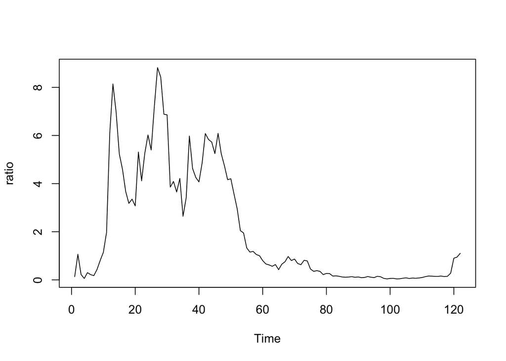

```r
plot.ts(time_ratio)
```

### Unforgiven came out in 1992. On the graph, I did not know how to annotate it, but looking at the time on the x axis and the western films ratio on the y axis, I don’t think that Unforgiven revived western films. The time period after the ’60s gets really flat and since the film came out in 1992, by that time, the line on the plot is still very flat.